# BirdNET to CSV:

## An alternative to BirdNET Analyzer for processing WAV files of bird calls into a CSV of identified species.

[output not shown]

## How it works

BirdNET to CSV is an executable file that is saved to and ran from the folder containing all the audio files that you want to have analyzed. The files can be within subfolders for your own organization, as the program will recursively search for any .wav file that exists in the folder it is ran from. Then after checking that any of the files have not been analyzed already, the files will be analyzed by the BirdNET machine learning algorithm and then appended to a CSV file. Because those results are appended to the CSV file intermittently, the user doesn't have to worry about losing progress in the event of a crash or power outage! Just restart the program to pick up where it left off. As the BirdNET python library does not have all the functionality of BirdNET Analyzer, BirdNET to CSV is a minimalist application that does not take much time to configure. The user does retain the ability to filter the possible bird species by location given by latitude and longitude. Inputting those values is the only interaction the user has to make with the application.

## But how fast is it?

I was curious about how BirdNET to CSV compared to BirdNET Analyzer and did an impromptu speed test with various numbers of files per job. The results are in the graph below. With just one file, BirdNET to CSV was able to start up much quicker than BirdNET Analyzer and maintained that speed (~52 seconds per file analyzed) no matter how many files it was analyzing. However BirdNET Analyzer uses multiple CPU threads to organize the tasks that the computer performs much more efficiently, and that becomes apparent as BirdNET Analyzer was able to increase its speed of analysis to below 40 seconds per file analyzed when it was given 50 files to work through. Despite this, BirdNET to CSV fills a niche of being an easy to use tool that can run in the background, such as when my project partners left it to run for two days while they went out into the field to continue collecting data. Hours of time was returned to them.

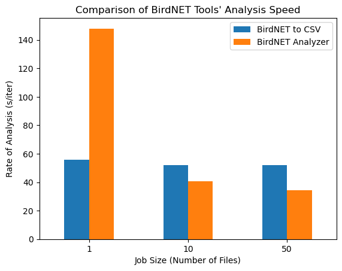

# What does the future hold?

Being able to process multiple files simultaneously would greatly improve the speed of BirdNET to CSV, so I would like to adapt the application to use the birdnet library's multiprocessing function. Additionally, I need to create a MacOS distribution. I created the current distribution with [PyInstaller](https://pyinstaller.org/en/stable/) since it packages in the version of the python environment that I used to create it. That made it easier for my partners to use since they didn't have to worry about creating a python environment or installing dependent software.

### Citations

Kahl, S., Wood, C. M., Eibl, M., & Klinck, H. (2021) BirdNET: A deep learning solution for avian diversity monitoring. Ecological Informatics, 61, 101236. https://doi.org/10.1016/j.ecoinf.2021.101236

MTBS Data Access: Fire Level Geospatial Data. (2025, April - Last Revised). MTBS Project (USDA Forest Service/ U.S. Geological Survey). Available Online: http://mtbs.gov/direct-download [2025, August 10].